# Assignment 3

–

October 24, 2017

## Question 1

## Question 2

If X and Y are random variables and:

$\mu_{X} = E(X) = 1$, $\mu_{Y} = E(Y) = 2$

$\sigma_{x} = SD(X) = 3$, $\sigma_{Y} = SD(Y) = 4$

$\rho_{XY} = CORR(X,Y) = 0.5$

Since we know $\rho_{XY}$ and we know that $\rho_{XY} = \frac{COV(X,Y)}{\sigma_{X} \sigma_{Y}}$ we can find $COV(X,Y)$:

$COV(X,Y) = \sigma_{X} \sigma_{Y} \rho_{XY} = 6$

#### a)

$E(2X - Y + 5)$ $= E(2X) + E(-Y) + E(5)$ $= 2E(X) - E(Y) + E(5)$ $= 2 - 2 + 5$ $= 5$

Therefore $E(2X - Y + 5) = 5$

#### b)

$VAR(2X - Y + 5)$ $= VAR(2X) + VAR(-Y) + VAR(5) + 2COV(2X,-Y) + 2COV(2X,5) + 2COV(-Y,5)$ $= VAR(2X) + VAR(-Y) + 2COV(2X,-Y)$ $= E((2X - 2\mu_{X})^2) + E(((-1)y - (-1)\mu_{Y})^2) + 2E((2X - 2\mu_{X})((-1)Y - (-1)\mu_{Y}))$ $= E(4(X-\mu_{X})^2) + E((1)(Y-\mu_{Y})^2) + 2E(2(X-\mu_{X})(-1)(Y-\mu_{Y}))$ $= 4E((X-\mu_{X})^2) + E((Y - \mu_{Y})^2) - 4E((X-\mu_{X})(Y-\mu_{Y}))$ $= 4\sigma^2_{X} + \sigma^2_{Y} - 4COV(X,Y)$ $= 4(9) + 16 - 4(6)$ $= 28$

$SD(2X - Y + 5) = \sqrt{VAR(2X - Y + 5)}$ $SD(2X - Y + 5) = 5.291503 \approx 5.29$

## Question 3

$\mu_{x} = \frac{2}{3}$, $\sigma^2_X=\frac{1}{18}$

We are assuming that $X_{1}, X_{2}, ...,X_{n}$ are iie (independent and identically distributed).

If $T = X_{1} + X{2} + X{3} + ... + X_{90} = \sum\limits^{90}_{i=1} X_{i}$ Then:

$E(T) = E(\sum\limits^{90}_{i=1} X_{i}) = \sum\limits^{90}_{i=1} X = nX = 60$

$VAR(T) = \sum\limits^{90}_{i=1} VAR(X) = \frac{90}{18} = 5$

By central limit theorem, T will be distributed $~N(60, \sqrt{5})$

Now, if we would like to find $P(T>65)$ we can use the standard normal distribtuion to easily find an approximate probability.

$Z= \frac{\bar{x} - \mu_{T}}{\sigma_{T}} = \frac{65-60}{\sqrt{5}} = 2.236$

The corresponding probability for $Z=2.236$ is $(1-\alpha) = 0.01257$. Therefore the probability that T is greater than 65, $P(T>65) \approx 0.01257$.

## Question 4

#### a) Finding the distribution

Just as a side note, CLT is commonly seen as effective when $n \geq 30$. Thus, in our case, finding the distribution using CLT should be an accurate estimation of the true distribution.

When rolling a dice the probability of any outcome $\Omega = \{1,2,3,4,5,6\}$ is $\frac{1}{6}$. We can also see each single event as distributed as a binomial with probability $\frac{1}{6}$. Thus:

$\mu_{X} = E(X) = (0)(1-p) + (1)p = p$

$\sigma_{X}^2 = E((X-\mu_{X})^2) = E((X-p)^2) = p(1-p) = \frac{5}{36}$

and $\bar{X}$ is a random variable with:

$\mu_{\bar{X}} = np$

$\sigma^2_{\bar{X}} = np(1-p)$

Note the variance is as such only because $X_1,X_2, ... ,X_{30}$ are iie.

Thus we can assume the distribution of $\bar_{X}$ to be as follows:

$\bar{X} \sim N(\mu_{\bar{X}}, \sigma_{\bar{X}})$

From here we can easily perform the Z transformation.

$\bar{X} \sim N(\frac{\mu_{\bar{X}} - np}{\sigma_{\bar{X}}}, \frac{\sigma_{\bar{X}}}{\sigma_{\bar{X}}})$

$\bar{X} \sim N(0, 1)$

#### b)

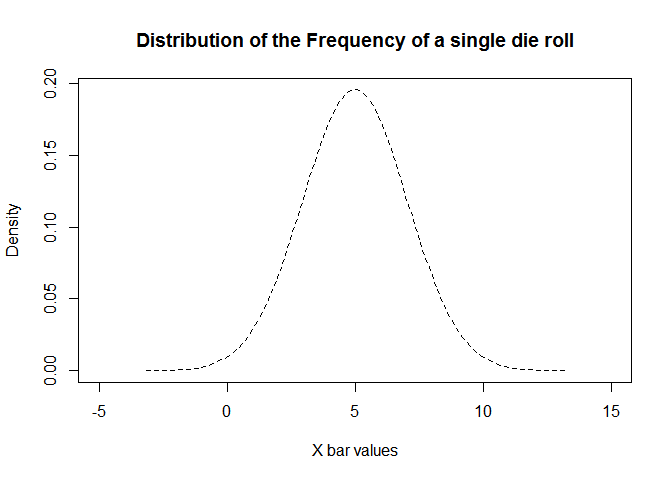

```r
n <- 30
p <- (1/6)
std <- sqrt(n*p*(1-p))
mu <- (n*p)

x <- seq(-4*std + mu, 4*std + mu, length=100)
hx <- dnorm(x, mean=mu, sd=std)

plot(x, hx, type="l", lty=2, xlab="X bar values",
     ylab="Density", main="Distribution of the Frequency of a single die roll", xlim=c(-5,15))
```

If we would like to plot the distribution for $\bar_{X}$, we can do the following:

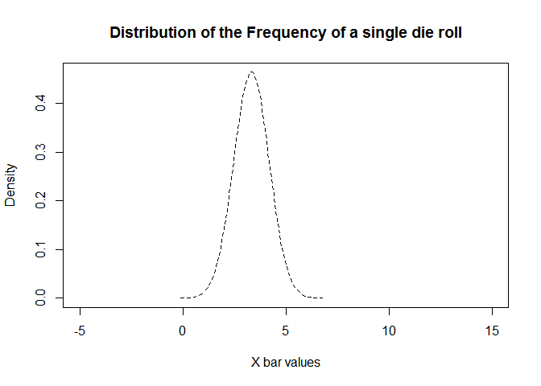

```r
mu <- 3.33
std <- sqrt(0.73926)

x <- seq(-4*std + mu, 4*std + mu, length=100)
hx <- dnorm(x, mean=mu, sd=std)

plot(x, hx, type="l", lty=2, xlab="X bar values",
     ylab="Density", main="Distribution of the Frequency of a single die roll", xlim=c(-5,15))
```

#### c)

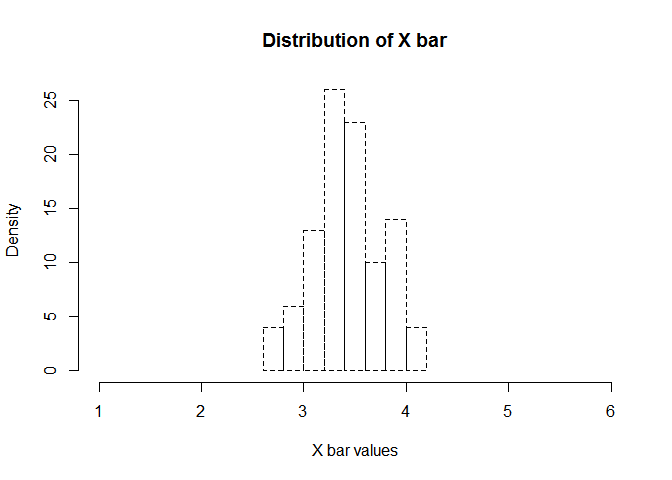

```r
thousand_samples <- c()
for(k in 1:100) {
  one_set <- c()
  for(i in 1:30) {
    one_set[i] <- sample(1:6, size=1, replace = TRUE, prob = NULL)
  }
  thousand_samples[k] <- mean(one_set)
}


hist(thousand_samples, lty=2, xlab="X bar values",
     ylab="Density", main="Distribution of X bar", xlim=c(30/n, 180/n))
```

#### d)

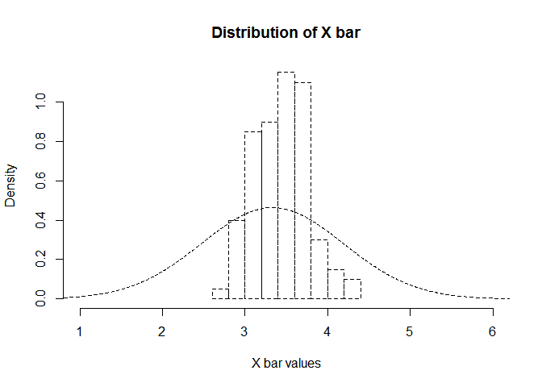

```r
par(mfrow=c(1,1))

# Using CLT
mu <- 3.33
std <- sqrt(0.73926)

x <- seq(-4*std + mu, 4*std + mu, length=1000)
hx <- dnorm(x, mean=mu, sd=std)


#Random Experiments
thousand_samples <- c()
for(k in 1:100) {
  one_set <- c()
  for(i in 1:30) {
    one_set[i] <- sample(1:6, size=1, replace = TRUE, prob = NULL)
  }
  thousand_samples[k] <- mean(one_set)
}


hist(thousand_samples, lty=2, xlab="X bar values",
     ylab="Density", main="Distribution of X bar", xlim=c(30/n, 180/n),freq = FALSE)


lines(x, hx, type="l", lty=2, xlab="X bar values",
     ylab="Density", main="Distribution of the Frequency of a single die roll", xlim=c(-5,15))
```

# Question 5

#### a)

$P(V_1 < -1.456)$

```r
pnorm(-1.456, mean=0, sd=1)
```

```
## [1] 0.07269631
```

#### b)

```r
1 - pt(2.155, df=14)
```

```
## [1] 0.02452893
```

#### c)

```r
pchisq(11.98, df=14)
```

```
## [1] 0.392091
```